# BayesMallows Demo

Eric Frey

2023-03-06

# Bayes Mallows Demo: Assessing Rankings of Movie Characters

This R Markdown document explores the BayesMallows R package, which is used for “analyzing data in the form of rankings or preferences with the Mallows rank model, in a Bayesian probabilistic framework.” (Sørensen et al. 2020)

To explore how this package works, we generate assessor rankings from true consensus ranking of movie characters.

We can generate a single assessor ranking from this true consensus ranking by sampling from a multinomial distribution without replacement until all items have been sampled. The ordered probabilities of this multinomial distribution represents the true consensus ranking.

Given a list of probabilities, where each element represents the probability of selecting that item:  
1. Initialize an empty list that will become an assessor’s ranking.  
2. Sample 1 item from the list of probabilities as though it were a multinomial probability distribution.  
3. Add this item to the assessor ranking list.  
4. Set this item’s probability of being selected to zero.  
5. Repeat 2-4, normalizing the remainder of the probability list until all items have been sampled.

# Load Libraries and Declare Functions

```r
# We load the required libraries for this analysis, including ggplot2, reshape2, and BayesMallows.
library(ggplot2)
suppressMessages(library(dplyr))
library(reshape2)
library(BayesMallows)

#we define two functions: normalize and generate_assessor_ranking. normalize normalizes a list of numbers by dividing each element by the sum of the list. generate_assessor_ranking generates an assessor ranking based on given probabilities (the true consensus ranking), sampling from this multinomial distribution.

# Function to normalize a list

normalize <- function(list1) { return(list1 / sum(list1)) }

# Function to generate an assessor ranking based on given probabilities

generate_assessor_ranking <- function(prob) {
  assessor_prob <- c()
  for (i in 1:length(prob)) {
    value <- which(rmultinom(1, 1, normalize(prob)) == 1)
    assessor_prob <- c(assessor_prob, value)
    prob[value] <- 0
  }
  return(assessor_prob)
}
```

# Data Generation

Here we specify our true consensus ranking, and generate assessors’ rankings on the basis of this true consensus over a set of 8 film characters. To generate a single observation consisting of an assessor’s ranked items, we sample from a multinomial distribution without replacement until all items have been sampled. The order of the ordered probabilities of this multinomial distribution represent the true consensus ranking. We repeat this sampling process for 50 assessors, thereby generating synthetic data based on a true consensus ranking.

```r
# Define Item Names and Rho
names = c("Frankenstein","Wednesday Addams", "The Grudge", "Noseferatu", "Freddy Krueger", "Dracula", "Dr. Frank N. Furter", "Pennywise")
probs = c(0.24169184, 0.21148036, 0.18126888, 0.15105740,0.09063444,  0.06042296,0.03323263, 0.03021148)


n_samples <- 50
set.seed(42)
# Generate Assessor Rankings
assessors = data.frame()
  for (i in 1:n_samples) {
    assessors = rbind(assessors, t(generate_assessor_ranking(probs)))
  }

#rename columns
names(assessors) <- names
print(paste('Characters and their average ranking from', n_samples, 'assesors'))
```

```
## [1] "Characters and their average ranking from 50 assesors"
```

```r
print(colMeans(assessors))
```

```
##        Frankenstein    Wednesday Addams          The Grudge          Noseferatu
##                2.80                3.76                3.14                3.86
##      Freddy Krueger             Dracula Dr. Frank N. Furter           Pennywise
##                4.04                5.30                5.88                7.22
```

# Preference Learning with the Mallows Rank Model

We use the Mallows Rank Model to analyze the assessors rankings. We compute the Mallows model with the compute_mallows function, specifying the use of the kendall distance, and plot the results with plot. As this package is authored by the same authors of Vitelli, V. (2019), the methods and algorithms used to estimate the posterior distribution are the same- the package utilizes the Metropolis-Hastings MCMC algorithm, and in order to sample from $\rho_m$ the Leap-Shift approach is implemented.

```r
# Preference Learning with the Mallows Rank Model
fit <- compute_mallows(assessors, metric="kendall")
```

Below is the pseudo code for this algorithm (Vitelli et al. 2014):

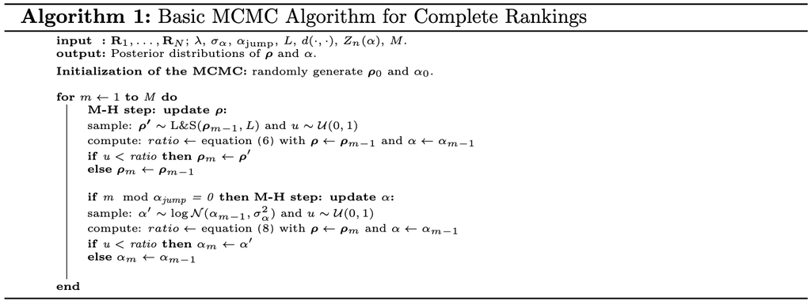

Where:

- Lambda $\lambda$ is the rate of the exponetial prior. By default this set to .001
- $\sigma_\alpha$ is the standard deviation of the lognormal proposal distribution used for $\alpha$. By default this set to .1.
- $\alpha_{jump}$ refers to how many times to sample $\rho$ between each sampling of $\alpha$. By default this is set to an integer of 1.
- $L$ is the step size of leap-and-shift proposal for $\rho$.
- $d$ is the right-invariant distance among rankings. We specify the Kendall distance.
- $Z_n(\alpha)$ is the normalizing constant. This is by default set to Null and gets computed during over iterations of the algorithm.
- $M$ is an integer specifying the number of iterations of the Metropolis-Hastings algorithm to run. By default this is set to an integer of 2000. $m$ is the current iteration.
- equation (6) refers to the ratio between the posterior distributions of $\rho\prime$ and $\rho_{m-1}$ given the data, as per the Metropolis Hastings MCMC algorithm.
- equation (8) refers to the ratio between the posterior distributions of $\alpha\prime$ and $\alpha_{m-1}$ given the data, as per the Metropolis Hastings MCMC algorithm.

# Assess Convergence

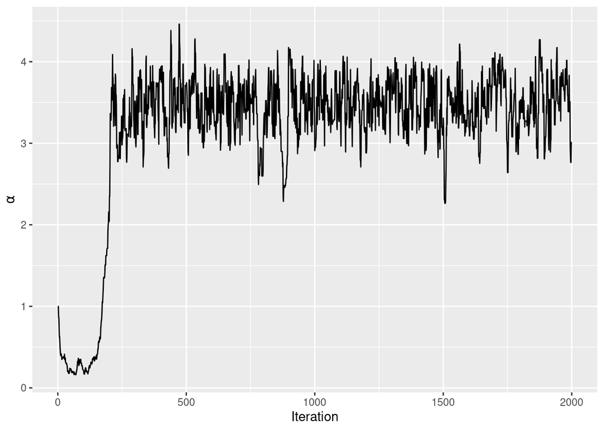

```r
assess_convergence(fit)
```

# Plot Estimated Rho

[figure not shown]

```r
#specify burnin
fit$burnin=100
rho_data <- plot(fit, parameter = "rho",items = 1:length(names))

# Create a data.frame with all possible combinations of letter and number
full_df <- expand.grid(item = levels(rho_data$data$item), value = unique(rho_data$data$value))

# Merge the two data.frames, setting missing values to 0
merged_df <- merge(full_df, rho_data$data[c("item", "value", "pct")], all.x = TRUE)
merged_df$pct[is.na(merged_df$pct)] <- 0
names(merged_df) <- c("item", "rank", "pct")

# Melt the data into long format
melted_df <- melt(merged_df, id.vars = c("item", "rank"))

rho_data
```

[figure not shown]

```r
# Create a Heatmap
ggplot(melted_df, aes(item, rank, fill= value)) +
  geom_tile(color = "black") +
  geom_text(aes(label = round(value, 2)), color = "white", size = 4) +
  coord_fixed() +
  scale_x_discrete(labels = c(names)) +
  theme(axis.text.x = element_text(angle = 45, vjust = 0.8)) +
  labs(fill="Posterior Probability")
```

```r
# Comparison of true consensus ranking with estimated
  compute_consensus(fit, type = "CP") %>%
    mutate(True_Consensus = names) %>%
    rename(Estimated_Consensus = item)
```

| ranking | Estimated_Consensus | cumprob | True_Consensus |
| --- | --- | --- | --- |
| 1 | The Grudge | 0.4942105 | Frankenstein |
| 2 | Frankenstein | 0.9578947 | Wednesday Addams |
| 3 | Wednesday Addams | 0.5363158 | The Grudge |
| 4 | Freddy Krueger | 0.6673684 | Noseferatu |
| 5 | Noseferatu | 0.9978947 | Freddy Krueger |
| 6 | Dracula | 1.0000000 | Dracula |
| 7 | Dr. Frank N. Furter | 1.0000000 | Dr. Frank N. Furter |
| 8 | Pennywise | 1.0000000 | Pennywise |

```r
# additional functions within Bayes Mallows package to display confidence intervals of true rank:
  # compute the confidence interval for the rankings of all the items
  compute_posterior_intervals(fit, parameter = "rho") %>%
    select(-hpdi)
```

| item | parameter | mean | median | conf_level | central_interval |
| --- | --- | --- | --- | --- | --- |
| Frankenstein | rho | 2 | 2 | 95 % | [1,3] |
| Wednesday Addams | rho | 4 | 3 | 95 % | [3,6] |
| The Grudge | rho | 2 | 2 | 95 % | [1,2] |
| Noseferatu | rho | 5 | 5 | 95 % | [2,5] |
| Freddy Krueger | rho | 4 | 4 | 95 % | [3,5] |
| Dracula | rho | 6 | 6 | 95 % | [4,6] |
| Dr. Frank N. Furter | rho | 7 | 7 | 95 % | [7] |
| Pennywise | rho | 8 | 8 | 95 % | [8] |

```r
  # compute confidence intervals for alpha
  compute_posterior_intervals(fit, parameter = "alpha")
```

| parameter | mean | median | conf_level | hpdi | central_interval |
| --- | --- | --- | --- | --- | --- |
| alpha | 3.312 | 3.438 | 95 % | [1.926,4.461] | [0.377,4.056] |

Here we display confidence intervals for both $\alpha$ and the rank of each item within a 95% degree of confidence.

# Comparison between Distance Metrics

```r
true = c("V1", "V2", "V3", "V4", "V5", "V6", "V7", "V8")
n_samples <- c(10, 30, 50, 70, 100)
d_metrics = c("footrule", "spearman", "cayley", "hamming", "kendall", "ulam")

# Create an empty data frame to store the results
results <- data.frame(n_samples = numeric(),
                      d_metric = character(),
                      log_likelihood = numeric(),
                      model_selection_score = numeric(),
                      computation_time = numeric())

# Loop over the sample sizes and distance metrics
for (n in n_samples) {
  for (seed in 1:20){

    # Generate Assessor Rankings
    assessors <- data.frame()

    set.seed(seed)
    for (i in 1:n) {
      assessors <- rbind(assessors, t(generate_assessor_ranking(probs)))
    }

    for (metric in d_metrics) {
      # Fit the Bayes Mallows model
      start_time <- Sys.time()
      fit <- compute_mallows(assessors, metric=metric)
      end_time <- Sys.time()
      computation_time <- end_time - start_time

      # Store the results in the data frame
      results <- rbind(results, data.frame(n_samples = n,
                                           d_metric = metric,
                                           model_selection_score = sum(true != compute_consensus(fit, burnin=250)$item),
                                           computation_time = computation_time))
    }
  }
  print(paste('sample size:', n))
}
```

```
## [1] "sample size: 10"
## [1] "sample size: 30"
## [1] "sample size: 50"
## [1] "sample size: 70"
## [1] "sample size: 100"
```

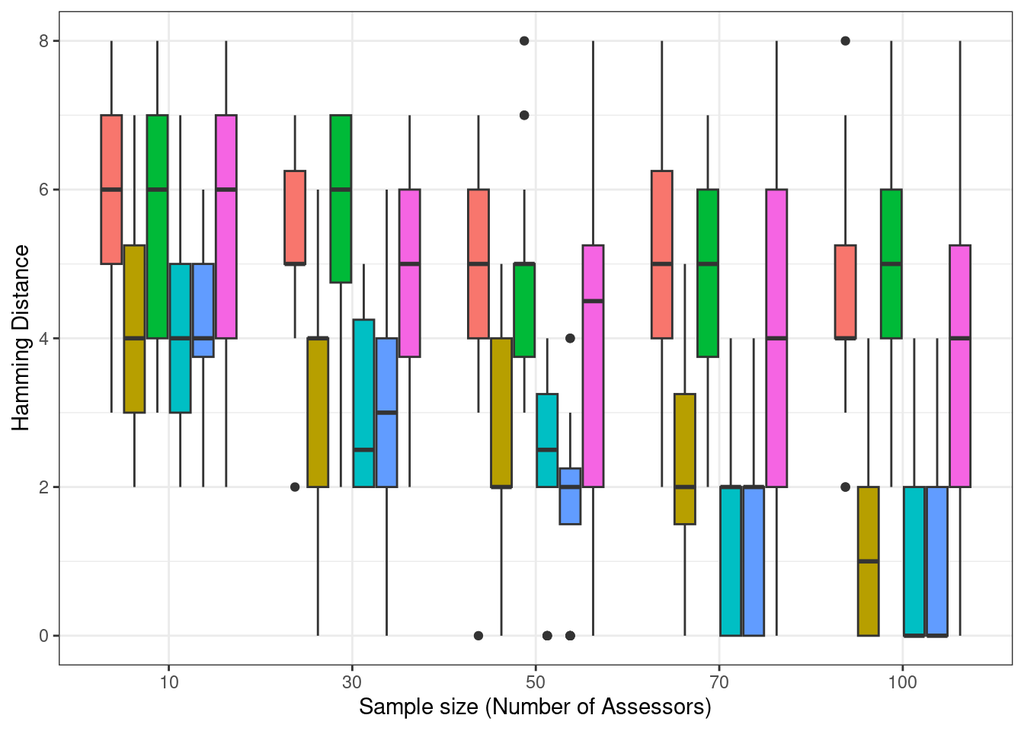

```r
# Visualize the results
library(ggplot2)

ggplot(results, aes(x = factor(n_samples), y = model_selection_score, fill = d_metric)) +
  geom_boxplot() +
  #scale_fill_manual(values = c("gray20", "gray50", "gray70", "gray80", "gray90", "white")) +
  labs(x = "Sample size (Number of Assessors)", y = "Hamming Distance", fill = "Distance metric") +
  theme_bw() +
  theme(legend.position = "none")
```

[figure not shown]

```r
# Visualize the computation results
ggplot(results[results$n_samples==500,], aes(x = factor(n_samples), y = as.numeric(computation_time), fill = d_metric)) +
  geom_boxplot() +
  labs(x = "Sample size (Number of Assessors)", y = "Computation Time (seconds)", fill = "Distance Metric") +
  theme_bw()
```

# References

Sørensen, Øystein, Marta Crispino, Qinghua Liu, and Valeria Vitelli. 2020. “BayesMallows: An r Package for the Bayesian Mallows Model.” *The R Journal* 12 (1): 324. https://doi.org/10.32614/rj-2020-026.

Vitelli, Valeria, Øystein Sørensen, Marta Crispino, Arnoldo Frigessi, and Elja Arjas. 2014. “Probabilistic Preference Learning with the Mallows Rank Model.” arXiv. https://doi.org/10.48550/ARXIV.1405.7945.